# Avaliação 2 - Valor: 33 pontos

Introdução à Ciência de Dados - 2025  
Bacharelado em Administração

Autores

Emanuely Arantes

João Pedro Oliveira

Mateus Bispo

Data de Publicação

18 de junho de 2025

## Questão 1

**a)**

```r
prob_sinistro <- 0.01
indenizacao_media <- 150000
premio_puro <- prob_sinistro * indenizacao_media
premio_puro
```

```
[1] 1500
```

**b)**

```r
# margem <- 0.25
margem <- 0.25                  # Margem de 25%
premio_comercial <- premio_puro * (1 + margem)
premio_comercial
```

```
[1] 1875
```

**c)**

```r
# fixa a semente para reprodutibilidade
set.seed(2025)

# simula o custo para 10 residências seguradas
custos_10 <- sample(
  c(0, 150000),        # sem sinistro ou com sinistro
  size = 10,           # número de residências
  replace = TRUE,      # com reposição
  prob = c(0.99, 0.01) # 99% chance de não sinistro
)

# imprime o vetor de custos simulados
print(custos_10)
```

```
 [1] 0 0 0 0 0 0 0 0 0 0
```

```r
# calcula o custo médio por apólice
mean(custos_10)
```

```
[1] 0
```

Simulação dos custos médios com 100 residências seguradas:

```r
# ## Simulação com 100 residências
set.seed(2025)
custos_100 <- sample(
  c(0, 150000),
  size = 100,
  replace = TRUE,
  prob = c(0.99, 0.01)
)
mean(custos_100)
```

```
[1] 4500
```

Simulação dos custos médios com 1000 residências seguradas:

```r
# ## Simulação com 1000 residências
set.seed(2025)
custos_1000 <- sample(
  c(0, 150000),
  size = 1000,
  replace = TRUE,
  prob = c(0.99, 0.01)
)
mean(custos_1000)
```

```
[1] 1500
```

**d)**A Lei dos Grandes Números justifica por que, nas simulações, os resultados se aproximam da média esperada quando o número de residências seguradas aumenta.

Na prática, isso significa que, ao simular sinistros para muitas casas, a média dos custos tende a ficar próxima do valor teórico de R$ 1.500 por apólice (calculado como 1% de R$ 150.000). Isso garante maior previsibilidade para a seguradora, que pode planejar melhor os prêmios e reduzir o risco de perdas inesperadas.

**e)**Ao incluir uma franquia de R$ 50.000, a seguradora passa a pagar apenas a parte do sinistro que excede esse valor. Assim, se o sinistro for de R$ 150.000, o pagamento da seguradora será de R$ 100.000.

Com esse novo valor, o custo médio esperado por apólice diminui, permitindo:

1. Reduzir o valor do prêmio cobrado ao cliente; ou
2. Manter o mesmo prêmio e obter uma margem de lucro maior.

Essa estratégia também ajuda a desestimular pedidos de sinistros de menor valor, pois o segurado participa do prejuízo, o que, em contrapartida, pode ser ruim para o segurado.

## Questão 2

**a)**

```r
## Parâmetros
media <- 5.9
desvio <- 1.1

# Probabilidade de ser maior que 8 dias
1 - pnorm(8, mean = media, sd = desvio)
```

```
[1] 0.02812518
```

**b)**

```r
# # Percentil de 90%
qnorm(0.90, mean = media, sd = desvio)
```

```
[1] 7.309707
```

**c)**

```r
# # Probabilidade de ser entregue em até 7 dias
pnorm(7, mean = media, sd = desvio)
```

```
[1] 0.8413447
```

## Questão 3

**a)**

```r
# # Valores conhecidos
media <- 18500
desvio <- 2300
valor <- 21800

# Cálculo do Z
z <- (valor - media) / desvio
z
```

```
[1] 1.434783
```

Resposta:O score Z de aproximadamente 1,43 indica que a loja vendeu 1,43 desvios-padrão acima da média naquele dia. Isso significa que o desempenho foi bem superior ao comum dentro da rede.

**b)**

```r
# # Probabilidade acumulada até esse Z
pnorm(z)
```

```
[1] 0.9243255
```

Como a empresa considera como “excepcional” o desempenho entre os 10% melhores (acima do percentil 90), esse caso atende ao critério. Portanto, sim, foi um dia excepcional.

Podemos usar percentil e probabilidade acumulada como sinônimos neste caso? Pergunta extra:Sim, neste contexto, probabilidade acumulada e percentil podem ser usados como sinônimos, pois ambos indicam a posição relativa da loja dentro da distribuição dos resultados.

## Questão 4

**a)**

```r
z <- qnorm(0.01)
desvio <- 0.045
var_percentual <- abs(z * desvio)
var_percentual
```

```
[1] 0.1046857
```

Cálculo do VaR 99% percentual:

```r
# # Parâmetros
desvio <- 0.045  # Desvio-padrão dos retornos mensais
z <- qnorm(0.01) # Quantil da normal para 1% (VaR 99%)

# Cálculo do VaR percentual
var_percentual <- abs(z * desvio)
var_percentual
```

```
[1] 0.1046857
```

Cálculo do VaR 99% monetário (valor absoluto da perda):

```r
# # Investimento atual
investimento <- 400000

# Cálculo do VaR monetário
var_monetario <- var_percentual * investimento
var_monetario
```

```
[1] 41874.26
```

**b)**Um VaR 99% de R$ 41.874,26 significa que, com base na distribuição normal dos retornos, a empresa tem 99% de confiança de que as perdas mensais não ultrapassarão esse valor. Apenas em 1% dos casos a perda pode ser maior.

**c)**Limitações da Normalidade

Caudas pesadas: Retornos financeiros muitas vezes têm perdas e ganhos extremos que a distribuição normal não prevê adequadamente.

Assimetria: Os retornos reais podem ter mais eventos negativos, o que a distribuição normal (simétrica) não representa bem

## Questão 5

- A
- B
- C
- D
- E

A opção D está correta. Pois o gráfico apresenta e mostra as taxas de feminicídio para cada 100 mil mulheres, e portanto, os países com taxas mais baixas de feminicídio terão uma posição mais baixa nesse ranking. As outras alternativas estão erradas, pois não encontramos a informação certa disponível nos gráficos e no texto. Santa Lúcia não é citada no texto e não é possível afirmar que ela apresenta uma das taxas mais baixas de feminicídio na região sem dados concretos. Além disso, o gráfico não apresenta um ranking, e sim uma lista de países com suas respectivas taxas de feminicídio. Por que as demais estão erradas?

- **Letra A** - O gráfico não foi feito somente para os cálculos de proporção. Na verdade, ele apresenta também dados absolutos e relativos para mostrar uma análise mias completa. A alternativa não vê isso.
- **Letra B** - Nos países como o Brasil, México e Argentina possuem os maiores números absolutos, mas as taxas por 100 mil mulheres não estão como as maiores. Os países com as maiores taxas são Honduras, EL Salvador e a República Dominicana. Então há uma confusão entre número absoluto e taxa proporcional, um erro nessa interpretação dos dados.
- **Letra C** - A alternativa B tem pouco fundamento, por falar de políticas públicas com base na análise de risco, mas ela não leva em conta a complexidade dos determinantes do feminicídio. Ela resume o problema ao focar só na autodefesa e nos comportamentos de riscos, ignorando que as mulheres nem sempre têm escolha dos seus contextos sociais, econômicos e culturais, que são os fatores e justamente as fontes que as colocam na situação de vulnerabilidade.
- **Letra E** - Ela está incorreta e contraditória. Essa alternativa mostra uma compreensão ruim e fraca da relação entre número o absoluto e taxa proporcional. O Brasil aparece com um alto número absoluto, mas não com uma das maiores taxas. Honduras, ao contrário do Brasil, tem uma taxa bem maior, o que indica mais risco, apesar do seu número absoluto ser menor. Isso acaba com a ideia de que o número relativo “vítima mais” no Brasil

## Questão 6

**a)**

```r
# library(tidyquant)
library(dplyr)
library(tidyr)

dados_precos <- c("PETR4.SA", "WEGE3.SA") %>%
  tq_get(from = "2024-01-01") %>%
  select(symbol, date, close) %>%
  pivot_wider(names_from = symbol, values_from = close) %>%
  rename(petrobras = `PETR4.SA`, weg = `WEGE3.SA`)

head(dados_precos)
```

```
# A tibble: 6 × 3
  date       petrobras   weg
  <date>         <dbl> <dbl>
1 2024-01-02      37.8  36.6
2 2024-01-03      39.0  36.8
3 2024-01-04      38.6  36.4
4 2024-01-05      38.7  36.0
5 2024-01-08      38.4  36.1
6 2024-01-09      38.1  35.2
```

**b.1)**

```r
dados_ret <- dados_precos %>%
  mutate(ret_petrobras = log(petrobras / lag(petrobras)),
         ret_weg       = log(weg       / lag(weg))) %>%
  drop_na()

head(dados_ret)
```

```
# A tibble: 6 × 5
  date       petrobras   weg ret_petrobras  ret_weg
  <date>         <dbl> <dbl>         <dbl>    <dbl>
1 2024-01-03      39.0  36.8       0.0308   0.00763
2 2024-01-04      38.6  36.4      -0.00851 -0.0134
3 2024-01-05      38.7  36.0       0.00233 -0.0108
4 2024-01-08      38.4  36.1      -0.00752  0.00250
5 2024-01-09      38.1  35.2      -0.00862 -0.0250
6 2024-01-10      37.8  35.3      -0.00923  0.00426
```

Por que usamos retorno? Usamos retornos para medir a variação relativa dos preços, o que permite comparar diferentes ativos. Além disso, os retornos têm escala padronizada e revelam a correlação entre os movimentos dos ativos — o que os preços brutos não conseguem mostrar.

**b.2)**

```r
correlacao <- cor(dados_ret$ret_petrobras, dados_ret$ret_weg)
print(correlacao)
```

```
[1] 0.1371311
```

**b.3)**

```r
# # Instala o pacote effectsize, se ainda não estiver instalado
install.packages("effectsize")

# Carrega o pacote
library(effectsize)

# Calcula a correlação entre os retornos
correlacao <- cor(dados_ret$ret_petrobras, dados_ret$ret_weg)

# Interpreta a magnitude da correlação com base em Cohen (1988)
interpretacao <- interpret_r(correlacao)

# Exibe o valor da correlação e sua interpretação
print(correlacao)
```

```
[1] 0.1371311
```

```r
print(interpretacao)
```

```
[1] "small"
(Rules: funder2019)
```

**c)**

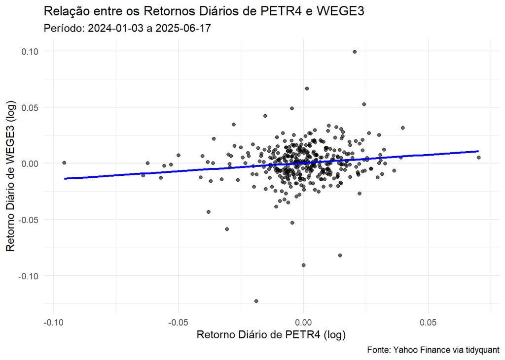

```r
# library(ggplot2)

# Determinar as datas de início e fim automaticamente do dataset
data_inicio <- min(dados_ret$date)
data_fim <- max(dados_ret$date)

# Criar gráfico
ggplot(dados_ret, aes(x = ret_petrobras, y = ret_weg)) +
  geom_point(alpha = 0.6) +
  geom_smooth(method = "lm", se = FALSE, color = "blue") +
  labs(
    title = "Relação entre os Retornos Diários de PETR4 e WEGE3",
    subtitle = paste("Período:", data_inicio, "a", data_fim),
    x = "Retorno Diário de PETR4 (log)",
    y = "Retorno Diário de WEGE3 (log)",
    caption = "Fonte: Yahoo Finance via tidyquant"
  ) +
  theme_minimal()
```

**d)** Mesmo com correlação fraca, a combinação de PETR4 e WEGE3 ajuda na diversificação da carteira. Isso porque os dois ativos não se movimentam sempre na mesma direção. Assim, as variações de um ativo podem ser compensadas pelo outro, reduzindo o risco total da carteira. Mesmo sem correlação negativa, uma fraca correlação já traz benefícios.